# Preliminary country cholera estimates

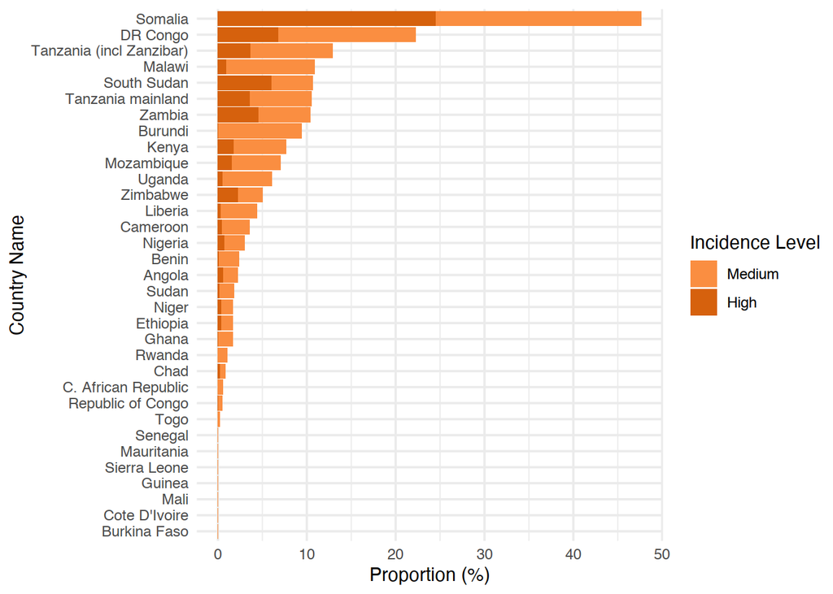

Figure 5: Percentage of the population living in areas with high and medium incidence levels over the 2015-2019 period, by country

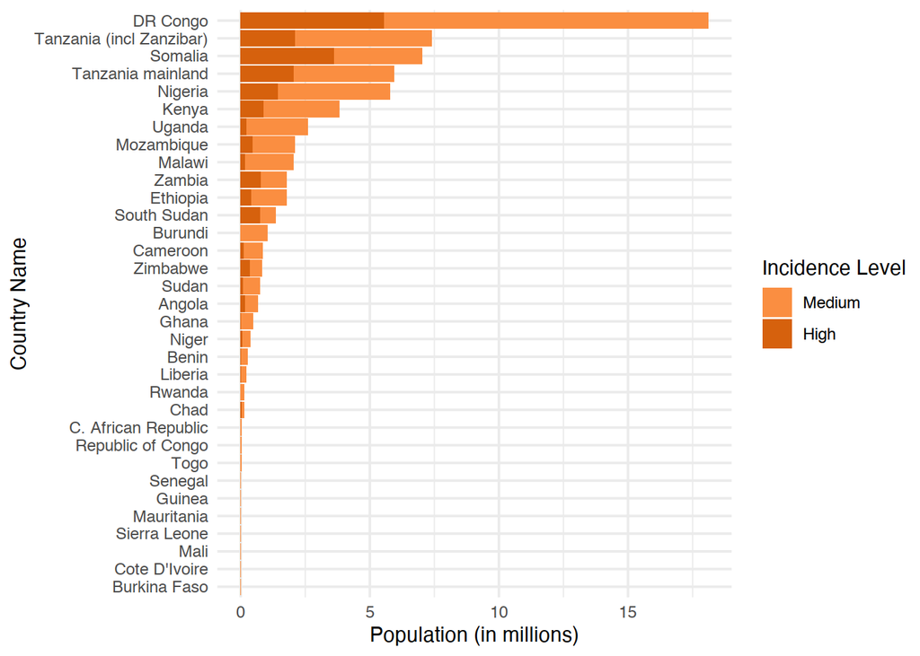

Figure 6: Size of the population living in areas with high and medium incidence levels over the 2015-2019 period, by country

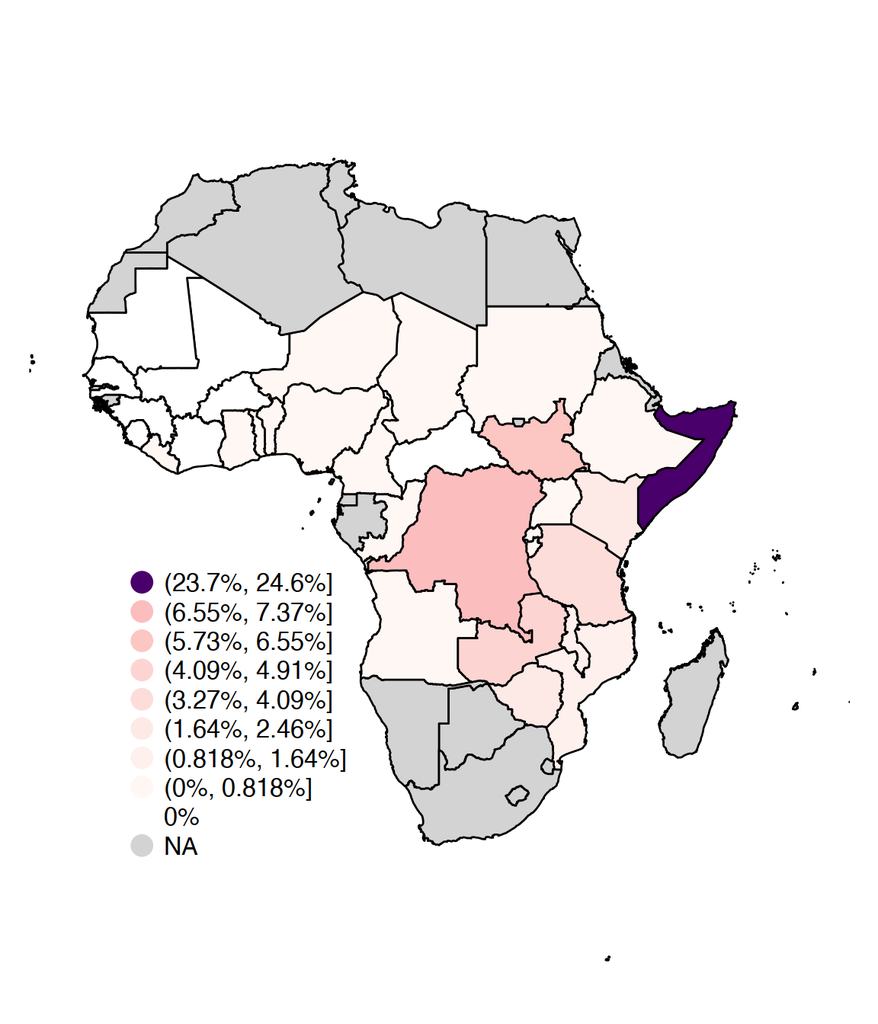

Figure 7: Percentage of the country population living in areas with a mean annual incidence rate ≥1 per 1,000 population over the 2015-2019 period

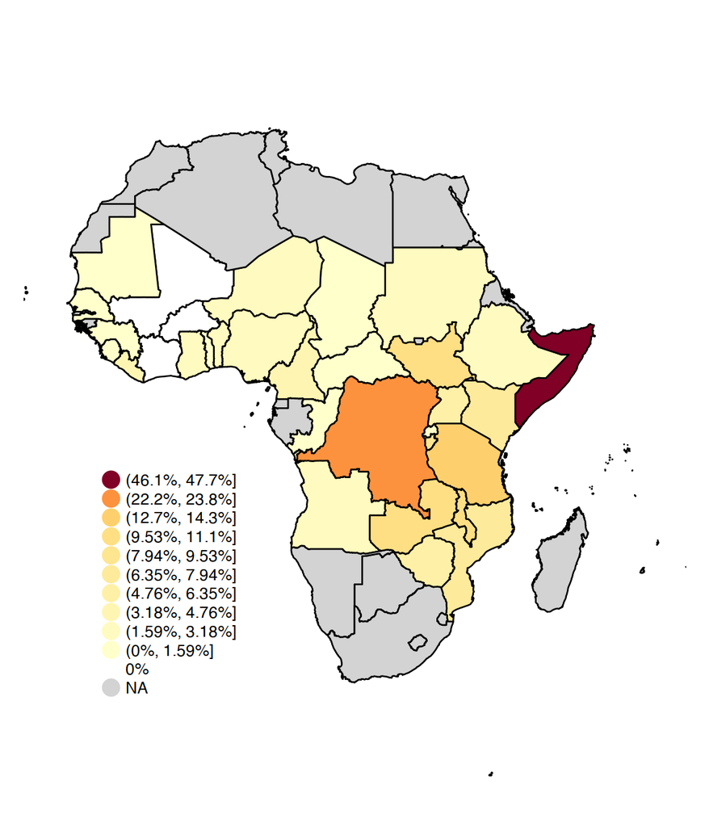

Figure 8: Percentage of the country population living in areas with a mean annual incidence rate ≥1 per 10,000 population over the 2015-2019 period

# Tables

Table 1: Mean annual incidence cases

| Country | Source | Years | Mean | 2.5% | 97.5% |
| --- | --- | --- | --- | --- | --- |
| Angola | JHU | 2015-2019 | 618 | 0 | 2369 |
| Angola | JHU | 2010-2016 | 2634 | 2605 | 2664 |
| Angola | WHO | 2015-2019 | 817 | 764 | 869 |
| Benin | JHU | 2015-2019 | 180 | 0 | 847 |
| Benin | JHU | 2010-2016 | 526 | 515 | 535 |
| Benin | WHO | 2015-2019 | 206 | 177 | 233 |
| Burkina Faso | JHU | 2015-2019 | 0 | 0 | 0 |
| Burkina Faso | JHU | 2010-2016 | 58 | 53 | 63 |
| Burkina Faso | WHO | 2015-2019 | 0 | 0 | 0 |
| Burundi | JHU | 2015-2019 | 504 | 90 | 1156 |
| Burundi | JHU | 2010-2016 | 653 | 634 | 671 |
| Burundi | WHO | 2015-2019 | 502 | 461 | 550 |
| C. African Republic | JHU | 2015-2019 | 36 | 0 | 180 |
| C. African Republic | JHU | 2010-2016 | 166 | 155 | 175 |
| C. African Republic | WHO | 2015-2019 | 0 | 0 | 0 |
| Cameroon | JHU | 2015-2019 | 562 | 20 | 1546 |
| Cameroon | JHU | 2010-2016 | 7572 | 7526 | 7619 |
| Cameroon | WHO | 2015-2019 | 760 | 704 | 811 |
| Chad | JHU | 2015-2019 | 358 | 0 | 1604 |
| Chad | JHU | 2010-2016 | 8904 | 8834 | 8975 |
| Chad | WHO | 2015-2019 | 453 | 412 | 495 |
| Cote D’Ivoire | JHU | 2015-2019 | 38 | 5 | 139 |
| Cote D’Ivoire | JHU | 2010-2016 | 498 | 483 | 512 |
| Cote D’Ivoire | WHO | 2015-2019 | 199 | 172 | 227 |
| DR Congo | JHU | 2015-2019 | 49062 | 35886 | 69505 |
| DR Congo | JHU | 2010-2016 | 23438 | 23338 | 23537 |
| DR Congo | WHO | 2015-2019 | 32907 | 32551 | 33270 |
| Eswatini | JHU | 2015-2019 | 0 | 0 | 0 |
| Eswatini | JHU | 2010-2016 | 1 | 1 | 1 |
| Eswatini | WHO | 2015-2019 | 0 | 0 | 0 |

[output cut: 81 more lines]

Table 2: Mean annual incidence rate per 10,000

| Country | Source | Years | Mean | 2.5% | 97.5% |
| --- | --- | --- | --- | --- | --- |
| Angola | JHU | 2015-2019 | 0.2080000 | 0.0000000 | 0.7950000 |
| Angola | JHU | 2010-2016 | 0.8670000 | 0.8580000 | 0.8770000 |
| Angola | WHO | 2015-2019 | 0.2690781 | 0.2515200 | 0.2860957 |
| Benin | JHU | 2015-2019 | 0.1610000 | 0.0000104 | 0.7580000 |
| Benin | JHU | 2010-2016 | 0.4630000 | 0.4540000 | 0.4720000 |
| Benin | WHO | 2015-2019 | 0.1810640 | 0.1559529 | 0.2053160 |
| Burkina Faso | JHU | 2015-2019 | 0.0000328 | 0.0000000 | 0.0000933 |
| Burkina Faso | JHU | 2010-2016 | 0.0295000 | 0.0271000 | 0.0321000 |
| Burkina Faso | WHO | 2015-2019 | 0.0000000 | 0.0000000 | 0.0000000 |
| Burundi | JHU | 2015-2019 | 0.4640000 | 0.0826000 | 1.0644000 |
| Burundi | JHU | 2010-2016 | 0.5920000 | 0.5750000 | 0.6090000 |
| Burundi | WHO | 2015-2019 | 0.4556748 | 0.4181251 | 0.4988478 |
| C. African Republic | JHU | 2015-2019 | 0.0766000 | 0.0000127 | 0.3870000 |
| C. African Republic | JHU | 2010-2016 | 0.3550000 | 0.3330000 | 0.3760000 |
| C. African Republic | WHO | 2015-2019 | 0.0000000 | 0.0000000 | 0.0000000 |
| Cameroon | JHU | 2015-2019 | 0.2340000 | 0.0084100 | 0.6430000 |
| Cameroon | JHU | 2010-2016 | 3.0381500 | 3.0196500 | 3.0571500 |
| Cameroon | WHO | 2015-2019 | 0.3047494 | 0.2824700 | 0.3254238 |
| Chad | JHU | 2015-2019 | 0.2400000 | 0.0000004 | 1.0767000 |
| Chad | JHU | 2010-2016 | 5.8317500 | 5.7854800 | 5.8784600 |
| Chad | WHO | 2015-2019 | 0.2966909 | 0.2698381 | 0.3241987 |
| Cote D’Ivoire | JHU | 2015-2019 | 0.0156000 | 0.0019700 | 0.0571000 |
| Cote D’Ivoire | JHU | 2010-2016 | 0.2010000 | 0.1950000 | 0.2060000 |
| Cote D’Ivoire | WHO | 2015-2019 | 0.0802348 | 0.0693487 | 0.0915241 |
| DR Congo | JHU | 2015-2019 | 6.0317300 | 4.4119000 | 8.5450500 |
| DR Congo | JHU | 2010-2016 | 2.8272000 | 2.8151400 | 2.8391500 |
| DR Congo | WHO | 2015-2019 | 3.9693874 | 3.9263944 | 4.0131344 |
| Eswatini | JHU | 2015-2019 | 0.0000000 | 0.0000000 | 0.0000000 |
| Eswatini | JHU | 2010-2016 | 0.0051600 | 0.0051600 | 0.0051600 |
| Eswatini | WHO | 2015-2019 | 0.0000000 | 0.0000000 | 0.0000000 |

[output cut: 81 more lines]

Table 3: Percentage of the population living in areas with high, medium, and low incidence levels over the 2015-2019 period

| Country | High incidence area proportion (%) | Medium incidence area proportion (%) | Low incidence area proportion (%) |
| --- | --- | --- | --- |
| Angola | 0.64 | 1.59 | 5.07 |
| Benin | 0.13 | 2.21 | 5.71 |
| Burkina Faso | 0.00 | 0.00 | 0.00 |
| Burundi | 0.08 | 9.30 | 57.42 |
| C. African Republic | 0.00 | 0.53 | 19.01 |
| Cameroon | 0.50 | 3.06 | 5.21 |
| Chad | 0.29 | 0.52 | 0.52 |
| Cote D’Ivoire | 0.00 | 0.00 | 2.02 |
| DR Congo | 6.85 | 15.41 | 22.90 |
| Ethiopia | 0.39 | 1.29 | 1.63 |
| Ghana | 0.04 | 1.61 | 4.46 |
| Guinea | 0.00 | 0.01 | 0.07 |
| Kenya | 1.79 | 5.87 | 5.56 |
| Liberia | 0.31 | 4.06 | 16.80 |
| Malawi | 0.99 | 9.88 | 21.06 |
| Mali | 0.00 | 0.00 | 0.00 |
| Mauritania | 0.00 | 0.02 | 0.13 |
| Mozambique | 1.58 | 5.43 | 7.01 |
| Niger | 0.39 | 1.29 | 1.63 |
| Nigeria | 0.76 | 2.26 | 3.83 |
| Republic of Congo | 0.07 | 0.38 | 3.48 |
| Rwanda | 0.01 | 1.03 | 6.94 |
| Senegal | 0.00 | 0.02 | 0.21 |
| Sierra Leone | 0.00 | 0.01 | 0.03 |
| Somalia | 24.55 | 23.09 | 19.03 |
| South Sudan | 6.09 | 4.54 | 5.59 |
| Sudan | 0.23 | 1.56 | 5.83 |
| Tanzania (incl Zanzibar) | 3.69 | 9.22 | 13.15 |
| Tanzania mainland | 3.63 | 6.87 | 12.80 |
| Togo | 0.01 | 0.22 | 2.09 |
| Uganda | 0.57 | 5.50 | 14.82 |
| Zambia | 4.58 | 5.80 | 7.98 |
| Zanzibar, Tanzania | 20.00 | 40.00 | 0.00 |
| Zimbabwe | 2.28 | 2.70 | 11.71 |

# Methods

## 2015-2019 JHU mean annual incidence estimates

We used suspected cholera surveillance reports at different administrative unit levels from the GTFCC cholera database to estimate the mean annual incidence of suspected cholera from 2015-2019 by 20 km x 20 km grid cells in a spatial Bayesian hierarchical modeling framework. The underlying cholera reports come from diverse sources ranging from weekly situational reports, NGO and outbreak reports, peer-reviewed literature, and the WHO. Multiple reports from different sources covering the same outbreak were considered to be independent observations of the same underlying process, thus contributing to measurement error in the reported case counts.

Countries were modeled separately, and model structures varied slightly between country to achieve better fits. Reported case counts were modeled with a Poisson distribution, and model terms include: a gridded covariate of distance to water, a spatial smoothing term similar to a conditional autoregressive (CAR) term ([Datta et al. (2019)](https://projecteuclid.org/journals/bayesian-analysis/volume-14/issue-4/Spatial-Disease-Mapping-Using-Directed-Acyclic-Graph-Auto-Regressive-DAGAR/10.1214/19-BA1177.full)), and a yearly random effect.

Model estimation was implemented with a Markov Chain Monte Carlo procedure in RStan with 4 chains and 2000 iterations (1000 final posterior draws). Case counts were summed for all grid cells in the country to develop a set of posterior estimates at the country level. Incidence rate was calculated as country case counts divided by population, and population estimates were derived from the UN World Population Prospects.

## 2010-2016 JHU mean annual incidence estimates

These estimates match the data reported in Lessler and Moore et al. (2018).

## WHO reference data

These country-level reports are taken from the WHO annual cholera reports published each year in the WER Bulletin. We calculated the mean annual incidence across 2015-2019 as a point of comparison for the new mean annual incidence estimates. Poisson-distributed variability was used to produce 95% CIs for WHO estimates.

For questions contact Elizabeth Lee at elizabeth.c.lee@jhu.edu